# Project: Investigate the TMDB movie database

## Introduction

I selected the TMDb database for this analysis: the dataset contains information about 10.000 movies.

This analysis will look at movie directors and their relationship with revenues. We will try to answers questions like:

- Which movie directors earned the most?
- Do movie directors have a track record? How many movies did they produced?
- Are they efficient with their budget?

No machine learning and/or descriptive statistics have been used, findings are then tentative.

### Notes about the dataset:

> Certain columns, like ‘cast’ and ‘genres’, contain multiple values separated by pipe (|) characters. There are some odd characters in the ‘cast’ column. Don’t worry about cleaning them. You can leave them as is. The final two columns ending with “_adj” show the budget and revenue of the associated movie in terms of 2010 dollars, accounting for inflation over time.

More info at: https://www.kaggle.com/tmdb/tmdb-movie-metadata

```python
# importing the needed libraries and the dataset

import pandas as pd
import matplotlib.pyplot as plt
import numpy as np
import seaborn as sns

%matplotlib inline
```

## Data Wrangling

### General Properties

```python
#load the data, we will force UTF8 enconding because of the accents of some movie director names
df = pd.read_csv('tmdb-movies.csv', encoding = 'utf8');
df.head(3)
```

|  | id | imdb_id | popularity | budget | revenue | original_title | cast | homepage | director | tagline | ... | overview | runtime | genres | production_companies | release_date | vote_count | vote_average | release_year | budget_adj | revenue_adj |
| --- | --- | --- | --- | --- | --- | --- | --- | --- | --- | --- | --- | --- | --- | --- | --- | --- | --- | --- | --- | --- | --- |
| 0 | 135397 | tt0369610 | 32.985763 | 150000000 | 1513528810 | Jurassic World | Chris Pratt\|Bryce Dallas Howard\|Irrfan Khan\|Vi... | http://www.jurassicworld.com/ | Colin Trevorrow | The park is open. | ... | Twenty-two years after the events of Jurassic ... | 124 | Action\|Adventure\|Science Fiction\|Thriller | Universal Studios\|Amblin Entertainment\|Legenda... | 6/9/15 | 5562 | 6.5 | 2015 | 1.379999e+08 | 1.392446e+09 |
| 1 | 76341 | tt1392190 | 28.419936 | 150000000 | 378436354 | Mad Max: Fury Road | Tom Hardy\|Charlize Theron\|Hugh Keays-Byrne\|Nic... | http://www.madmaxmovie.com/ | George Miller | What a Lovely Day. | ... | An apocalyptic story set in the furthest reach... | 120 | Action\|Adventure\|Science Fiction\|Thriller | Village Roadshow Pictures\|Kennedy Miller Produ... | 5/13/15 | 6185 | 7.1 | 2015 | 1.379999e+08 | 3.481613e+08 |
| 2 | 262500 | tt2908446 | 13.112507 | 110000000 | 295238201 | Insurgent | Shailene Woodley\|Theo James\|Kate Winslet\|Ansel... | http://www.thedivergentseries.movie/#insurgent | Robert Schwentke | One Choice Can Destroy You | ... | Beatrice Prior must confront her inner demons ... | 119 | Adventure\|Science Fiction\|Thriller | Summit Entertainment\|Mandeville Films\|Red Wago... | 3/18/15 | 2480 | 6.3 | 2015 | 1.012000e+08 | 2.716190e+08 |

3 rows × 21 columns

```python
# get the size of the dataset
df.shape
```

```
(10866, 21)
```

```python
# check for missing data and the type of data
df.info();
```

```
<class 'pandas.core.frame.DataFrame'>
RangeIndex: 10866 entries, 0 to 10865
Data columns (total 21 columns):
id                      10866 non-null int64
imdb_id                 10856 non-null object
popularity              10866 non-null float64
budget                  10866 non-null int64
revenue                 10866 non-null int64
original_title          10866 non-null object
cast                    10790 non-null object
homepage                2936 non-null object
director                10822 non-null object
tagline                 8042 non-null object
keywords                9373 non-null object
overview                10862 non-null object
runtime                 10866 non-null int64
genres                  10843 non-null object
production_companies    9836 non-null object
release_date            10866 non-null object
vote_count              10866 non-null int64
vote_average            10866 non-null float64
release_year            10866 non-null int64
budget_adj              10866 non-null float64
revenue_adj             10866 non-null float64
dtypes: float64(4), int64(6), object(11)
memory usage: 1.7+ MB
```

```python
# describe the dataset
df.describe()
```

|  | id | popularity | budget | revenue | runtime | vote_count | vote_average | release_year | budget_adj | revenue_adj |
| --- | --- | --- | --- | --- | --- | --- | --- | --- | --- | --- |
| count | 10866.000000 | 10866.000000 | 1.086600e+04 | 1.086600e+04 | 10866.000000 | 10866.000000 | 10866.000000 | 10866.000000 | 1.086600e+04 | 1.086600e+04 |
| mean | 66064.177434 | 0.646441 | 1.462570e+07 | 3.982332e+07 | 102.070863 | 217.389748 | 5.974922 | 2001.322658 | 1.755104e+07 | 5.136436e+07 |
| std | 92130.136561 | 1.000185 | 3.091321e+07 | 1.170035e+08 | 31.381405 | 575.619058 | 0.935142 | 12.812941 | 3.430616e+07 | 1.446325e+08 |
| min | 5.000000 | 0.000065 | 0.000000e+00 | 0.000000e+00 | 0.000000 | 10.000000 | 1.500000 | 1960.000000 | 0.000000e+00 | 0.000000e+00 |
| 25% | 10596.250000 | 0.207583 | 0.000000e+00 | 0.000000e+00 | 90.000000 | 17.000000 | 5.400000 | 1995.000000 | 0.000000e+00 | 0.000000e+00 |
| 50% | 20669.000000 | 0.383856 | 0.000000e+00 | 0.000000e+00 | 99.000000 | 38.000000 | 6.000000 | 2006.000000 | 0.000000e+00 | 0.000000e+00 |
| 75% | 75610.000000 | 0.713817 | 1.500000e+07 | 2.400000e+07 | 111.000000 | 145.750000 | 6.600000 | 2011.000000 | 2.085325e+07 | 3.369710e+07 |
| max | 417859.000000 | 32.985763 | 4.250000e+08 | 2.781506e+09 | 900.000000 | 9767.000000 | 9.200000 | 2015.000000 | 4.250000e+08 | 2.827124e+09 |

Since this analysis will try to cover the relations between revenue, ratings and directors, we will first drop columns about the id, cast and plot. We will also fix the dates from sting to a date type.

```python
#dropping columns not needed in this research
df = df.drop(['imdb_id','id','keywords','cast','homepage','tagline','production_companies','overview'], axis=1)
```

```python
# turn release_date from string to datetime type
df['release_date'] = pd.to_datetime(df['release_date'])
```

Also, to avoid showing the scientific notation in budget_adj and revenue_adj columns, we will turn them from float to int

```python
df['budget_adj'] = df['budget_adj'].astype(int)
df['revenue_adj'] = df['revenue_adj'].astype(int)
```

```python
#check how the dataset has changed
df.head(1)
```

|  | popularity | budget | revenue | original_title | director | runtime | genres | release_date | vote_count | vote_average | release_year | budget_adj | revenue_adj |
| --- | --- | --- | --- | --- | --- | --- | --- | --- | --- | --- | --- | --- | --- |
| 0 | 32.985763 | 150000000 | 1513528810 | Jurassic World | Colin Trevorrow | 124 | Action\|Adventure\|Science Fiction\|Thriller | 2015-06-09 | 5562 | 6.5 | 2015 | 137999939 | 1392445892 |

### Data Cleaning

One of the first thing that we can see is that some movies have revenues equal to zero. Considering that the lowest grossing movie in history made thirty dollars, zero is a situation where we have incorrect data and/or missing data.

Source: https://screenrant.com/lowest-grossing-movies-ever-all-time-box-office/

We will then remove the rows where revenue and budget are zero.

```python
# reassign the dataset by keeping only the rows with revenue_adj above zero.
df = df.query('revenue_adj > 0')
```

```python
# still, some rows might have revenue information but no budget information. We will check them now
df.query('budget_adj == 0').count()
```

```
popularity        996
budget            996
revenue           996
original_title    996
director          996
runtime           996
genres            996
release_date      996
vote_count        996
vote_average      996
release_year      996
budget_adj        996
revenue_adj       996
dtype: int64
```

```python
# remove the rows without budget information
df = df.query('budget_adj > 0')
```

## Exploratory Data Analysis

Now that we have a dataset with only information with both revenues and budget, we will start to look into the top directors. The first operation is to find the average revenue in the dataset, and use that average revenue to divide the dataset in high performing movies and low performing movies.

```python
# to draw a line, we will find the average adjusted earning in the database
# 134534471
np.round_(df['revenue_adj'].mean(), decimals=0)
```

```
134534471.0
```

From the cleaned dataset, the average revenue ofa movie is 134534471. We will use this value to create a dataset for the top movies and one for the bottom movies.

```python
# we will now create two dataset. One for movies above average and one for movies earning below average.
df_top = df.query('revenue_adj > 134534471')
df_bottom = df.query('revenue_adj <= 134534471')
```

### So, who directed the movies with the highest revenues?

Before visualizing the data, we will see look who are the directors that, in total, made the movies with the highests revenues. We will look at the adjusted revenues to put them on-par with currency power along years.

```python
# https://stackoverflow.com/questions/21137150/format-suppress-scientific-notation-from-python-pandas-aggregation-results/47638627
# because on groupby I will still see scientific notation number, I used the above answer to suppress it.
pd.set_option('display.float_format', lambda x: '%.2f' % x)
```

```python
# see the highest top 10 grossing directors
# https://stackoverflow.com/questions/20069009/pandas-good-approach-to-get-top-n-records-within-each-group
df_top.groupby(['director'])['revenue_adj'].sum().nlargest(10)
```

```
director
Steven Spielberg    14819501656.00
Peter Jackson        6879110034.00
Robert Zemeckis      5568361711.00
Michael Bay          5380009007.00
Chris Columbus       4735465262.00
Tim Burton           4245179206.00
David Yates          4177455258.00
Roland Emmerich      4076808329.00
Christopher Nolan    3995327387.00
Gore Verbinski       3828613744.00
Name: revenue_adj, dtype: float64
```

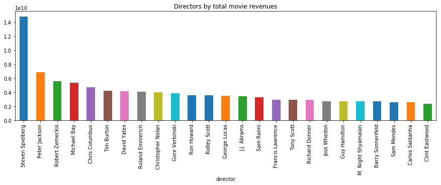

```python
data = df_top.groupby(['director'])['revenue_adj'].sum().nlargest(25);
data.plot(kind="bar", figsize=(15,4), title="Directors by total movie revenues");
del data;
```

```python
#get the most productive movie directors
df_top.groupby(['director'])['revenue_adj'].count().nlargest(10)
```

```
director
Steven Spielberg    23
Robert Zemeckis     13
Tim Burton          11
Clint Eastwood      10
Michael Bay         10
Ridley Scott        10
Tony Scott          10
Ron Howard           9
Brett Ratner         8
David Fincher        8
Name: revenue_adj, dtype: int64
```

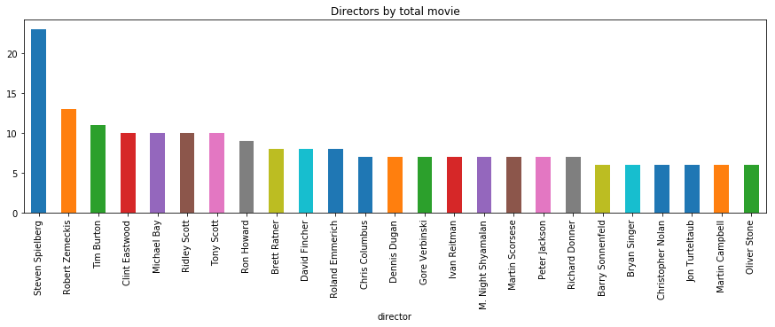

```python
data = df_top.groupby(['director'])['revenue_adj'].count().nlargest(25);
data.plot(kind="bar", figsize=(15,4), title="Directors by total movie");
del data;
```

Here again: Steven Spielberg. Not only his movies had the best revenues, but he also scored 23 movies with earnings above average. We also see other names that directed several movies with above-average earnings and, some of them, are also the ones that grossed the most (see Tim Burton or Michael Bay). What about critics?

```python
#get the most productive movie directors
df_top.groupby(['director'])['vote_average'].mean().nlargest(10)
```

```
director
Alfred Hitchcock          8.00
Frank Darabont            8.00
MiloÅ¡ Forman             8.00
Morten Tyldum             8.00
Pete Docter               8.00
Billy Wilder              7.90
James Gunn                7.90
Steve McQueen             7.90
Wes Anderson              7.90
Don Hall|Chris Williams   7.80
Name: vote_average, dtype: float64
```

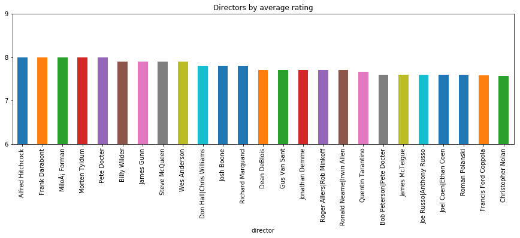

```python
data = df_top.groupby(['director'])['vote_average'].mean().nlargest(25);
data.plot(kind="bar", figsize=(15,4), title="Directors by average rating", ylim=(6,9), yticks=(6,7,8,9));
del data;
```

We will now create a brand new dataset focused on movie directors, seeing how much they grossed at the box office, how many movies, etc...

```python
#now we will create different dataset to summarise the needed stats
# this answer help me add as_index false. Before I was loosing column names
# https://stackoverflow.com/questions/44416287/renaming-columns-after-group-by-and-sum-in-pandas-dataframe
df_top_revenue = df_top.groupby(['director'], as_index=False)['revenue_adj'].sum()
df_top_budget = df_top.groupby(['director'], as_index=False)['budget_adj'].sum()
df_top_count = df_top.groupby(['director'], as_index=False)['vote_count'].count()
df_top_average = df_top.groupby(['director'], as_index=False)['vote_average'].mean()
```

```python
# create a new dataset by concatenating the four previous ones
df_top_dir = pd.concat([df_top_revenue, df_top_budget, df_top_count, df_top_average], ignore_index=True, axis=1)
```

```python
# drop the extra column
df_top_dir.drop([2,4,6], axis=1, inplace=True)
```

```python
# rename the new columns
df_top_dir.columns = ['director','revenue_adj','budget_adj','movies','average_vote']
```

```python
# see the new dataset
df_top_dir.head(2)
```

|  | director | revenue_adj | budget_adj | movies | average_vote |
| --- | --- | --- | --- | --- | --- |
| 0 | Adam McKay | 509249683.00 | 225222680 | 3 | 6.10 |
| 1 | Adam Shankman | 517103216.00 | 171723779 | 3 | 5.63 |

```python
df_top_dir.describe()
```

|  | revenue_adj | budget_adj | movies | average_vote |
| --- | --- | --- | --- | --- |
| count | 549.00 | 549.00 | 549.00 | 549.00 |
| mean | 735850027.53 | 168120354.68 | 2.07 | 6.40 |
| std | 1017110968.69 | 217042486.66 | 1.95 | 0.66 |
| min | 134697582.00 | 15775.00 | 1.00 | 4.10 |
| 25% | 211811410.00 | 42929006.00 | 1.00 | 5.95 |
| 50% | 415900961.00 | 96881146.00 | 1.00 | 6.40 |
| 75% | 835111182.00 | 186968356.00 | 2.00 | 6.90 |
| max | 14819501656.00 | 1854562195.00 | 23.00 | 8.00 |

### The new dataset

We will start now look at the first correlations in this new dataset by plotting a grid of charts.

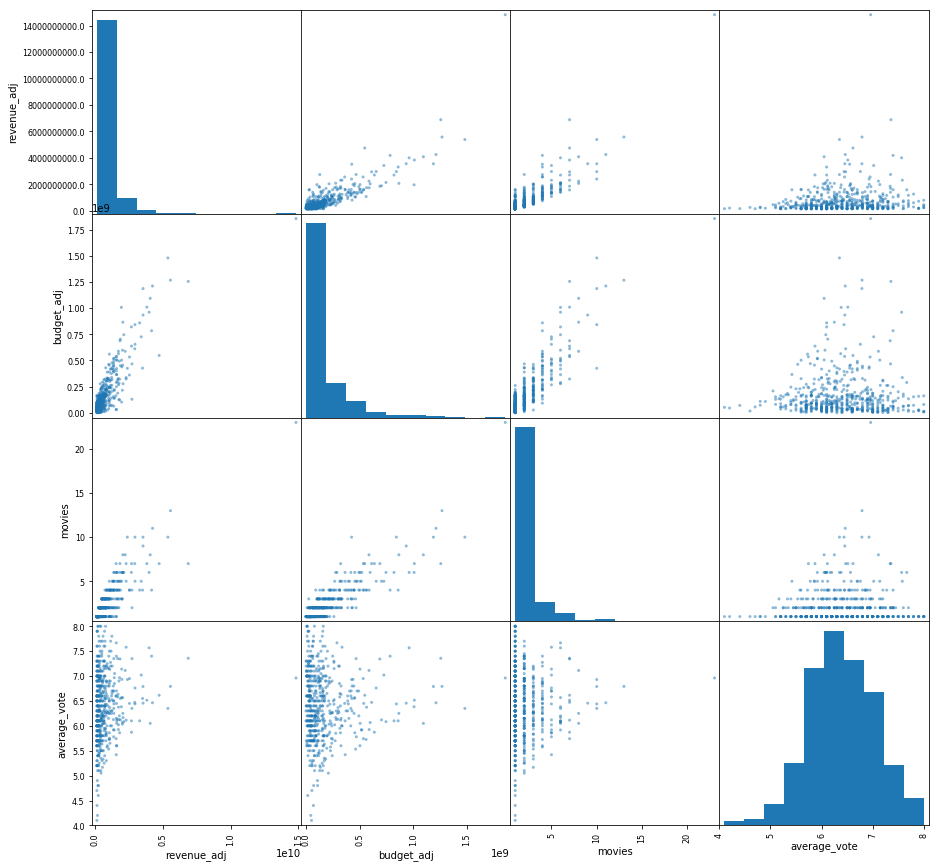

```python
# create a scatter matrix to first evaluate the new dataset
pd.plotting.scatter_matrix(df_top_dir, figsize=(15,15));
```

On the first observations, we see that:

- Average votes have a distribution slighly skewed to the left.
- Looking again at a distribution, the movies per director are strongly skewed to the right. The majority of the directors produced 5 or less movies that grossed more than average.

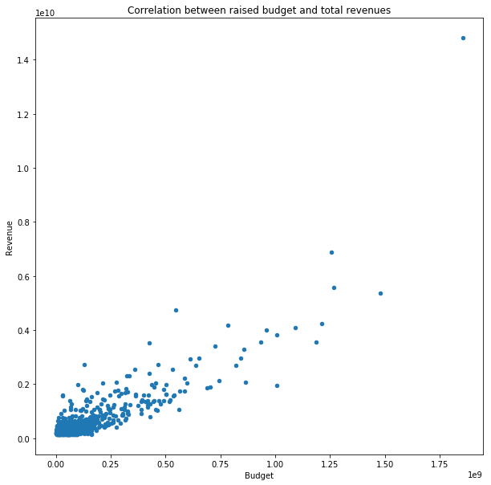

```python
df_top_dir.plot(kind="scatter", x="budget_adj", y="revenue_adj", figsize=(10,10));
plt.title("Correlation between raised budget and total revenues");
plt.xlabel("Budget");
plt.ylabel("Revenue");
```

Apart from some outliers, to make revenue you need to be able to raise budget. That is the case of the top right corner, where Steven Spielger not only was able to gross more at the box office, but to obtain more budget than the others.

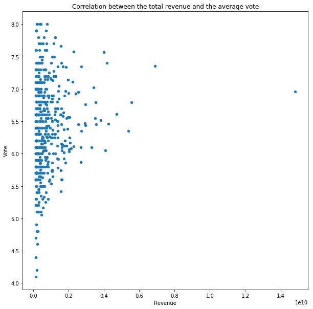

```python
df_top_dir.plot(kind="scatter", x="revenue_adj", y="average_vote", figsize=(10,10));
plt.title("Correlation between the total revenue and the average vote");
plt.xlabel("Revenue");
plt.ylabel("Vote");
```

Above we see the correlation about revenues and average vote. We see again the outlier named Steven Spielber where his movies do not top others in terms of average vote, but surpass every other director in terms of revenue.

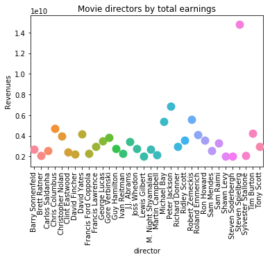

```python
data = df_top_dir.query('revenue_adj > 2000000000');
ax = sns.stripplot(x=data['director'], y=data['revenue_adj'], size=12);
ax.set_xticklabels(data['director'],rotation=90);
# ax.set_yticklabels(data['revenue_adj']); commented out for weird numbers of the y label
ax.set_ylabel('Revenues');
ax.set_title('Movie directors by total earnings');
del data;
```

Above an attempt to visualize top grossing directors with seaborn. Another view that shows the few directors that grossed more than 2 billions worldwide.

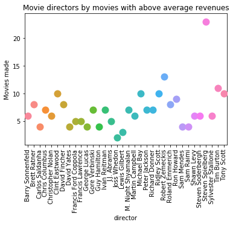

```python
data = df_top_dir.query('revenue_adj > 2000000000');
ax = sns.stripplot(x=data['director'], y=data['movies'], size=12);
ax.set_xticklabels(data['director'],rotation=90);
# ax.set_yticklabels(data['revenue_adj']); commented out for weird numbers of the y label
ax.set_ylabel('Movies made');
ax.set_title('Movie directors by movies with above average revenues');
del data;
```

Success is a matter of constance, and here again Spielberg surpass everyone else for being so prolific.

## Conclusions

Defining a "good" director can be subjective, we see how directors that on average scored better ratings are not the ones with the highest movie revenues. We also see that, on a dataset of movies grossing more than average, the distribution of ratings is distributed between 4 and 8: even bad movies can have good revenues.

But, talking about reviews or talking about box office, there is one common point: constance is required.